### Etudiant: IMN

# 1) Exploration de nos données

```python
import pandas as pd
import matplotlib.pyplot as plt
import seaborn as sns
import numpy as np
```

```python
df=pd.read_csv("C:\\Users\\HP\\Desktop\\Données\\diabetes.csv")
```

```python
df.head()
```

|  | Pregnancies | Glucose | BloodPressure | SkinThickness | Insulin | BMI | DiabetesPedigreeFunction | Age | Outcome |
| --- | --- | --- | --- | --- | --- | --- | --- | --- | --- |
| 0 | 6 | 148 | 72 | 35 | 0 | 33.6 | 0.627 | 50 | 1 |
| 1 | 1 | 85 | 66 | 29 | 0 | 26.6 | 0.351 | 31 | 0 |
| 2 | 8 | 183 | 64 | 0 | 0 | 23.3 | 0.672 | 32 | 1 |
| 3 | 1 | 89 | 66 | 23 | 94 | 28.1 | 0.167 | 21 | 0 |
| 4 | 0 | 137 | 40 | 35 | 168 | 43.1 | 2.288 | 33 | 1 |

=====================================================================================================================

====================================================================================================================

#### Information sur le dataset

```python
df.info()
```

```
<class 'pandas.core.frame.DataFrame'>
RangeIndex: 768 entries, 0 to 767
Data columns (total 9 columns):
 #   Column                    Non-Null Count  Dtype
---  ------                    --------------  -----
 0   Pregnancies               768 non-null    int64
 1   Glucose                   768 non-null    int64
 2   BloodPressure             768 non-null    int64
 3   SkinThickness             768 non-null    int64
 4   Insulin                   768 non-null    int64
 5   BMI                       768 non-null    float64
 6   DiabetesPedigreeFunction  768 non-null    float64
 7   Age                       768 non-null    int64
 8   Outcome                   768 non-null    int64
dtypes: float64(2), int64(7)
memory usage: 54.1 KB
```

```python
df.dtypes
```

```
Pregnancies                   int64
Glucose                       int64
BloodPressure                 int64
SkinThickness                 int64
Insulin                       int64
BMI                         float64
DiabetesPedigreeFunction    float64
Age                           int64
Outcome                       int64
dtype: object
```

==================================================================================================================

#### Les statisstiques du dataset

```python
df.describe()
```

|  | Pregnancies | Glucose | BloodPressure | SkinThickness | Insulin | BMI | DiabetesPedigreeFunction | Age | Outcome |
| --- | --- | --- | --- | --- | --- | --- | --- | --- | --- |
| count | 768.000000 | 768.000000 | 768.000000 | 768.000000 | 768.000000 | 768.000000 | 768.000000 | 768.000000 | 768.000000 |
| mean | 3.845052 | 120.894531 | 69.105469 | 20.536458 | 79.799479 | 31.992578 | 0.471876 | 33.240885 | 0.348958 |
| std | 3.369578 | 31.972618 | 19.355807 | 15.952218 | 115.244002 | 7.884160 | 0.331329 | 11.760232 | 0.476951 |
| min | 0.000000 | 0.000000 | 0.000000 | 0.000000 | 0.000000 | 0.000000 | 0.078000 | 21.000000 | 0.000000 |
| 25% | 1.000000 | 99.000000 | 62.000000 | 0.000000 | 0.000000 | 27.300000 | 0.243750 | 24.000000 | 0.000000 |
| 50% | 3.000000 | 117.000000 | 72.000000 | 23.000000 | 30.500000 | 32.000000 | 0.372500 | 29.000000 | 0.000000 |
| 75% | 6.000000 | 140.250000 | 80.000000 | 32.000000 | 127.250000 | 36.600000 | 0.626250 | 41.000000 | 1.000000 |
| max | 17.000000 | 199.000000 | 122.000000 | 99.000000 | 846.000000 | 67.100000 | 2.420000 | 81.000000 | 1.000000 |

===================================================================================================================

#### Le target( la variable à predire)

c'est la variable Outcome qui veut dire Resultats

=====================================================================================================================

#### Division notre dataset en deux classe:

la classe des personnes atteient du diabete etla casse des personnes non attaint

```python
df_yes=df[df['Outcome']==1]
df_non=df[df['Outcome']==0]
```

```python
df_yes.head()
```

|  | Pregnancies | Glucose | BloodPressure | SkinThickness | Insulin | BMI | DiabetesPedigreeFunction | Age | Outcome |
| --- | --- | --- | --- | --- | --- | --- | --- | --- | --- |
| 0 | 6 | 148 | 72 | 35 | 0 | 33.6 | 0.627 | 50 | 1 |
| 2 | 8 | 183 | 64 | 0 | 0 | 23.3 | 0.672 | 32 | 1 |
| 4 | 0 | 137 | 40 | 35 | 168 | 43.1 | 2.288 | 33 | 1 |
| 6 | 3 | 78 | 50 | 32 | 88 | 31.0 | 0.248 | 26 | 1 |
| 8 | 2 | 197 | 70 | 45 | 543 | 30.5 | 0.158 | 53 | 1 |

```python
df_non.head()
```

|  | Pregnancies | Glucose | BloodPressure | SkinThickness | Insulin | BMI | DiabetesPedigreeFunction | Age | Outcome |
| --- | --- | --- | --- | --- | --- | --- | --- | --- | --- |
| 1 | 1 | 85 | 66 | 29 | 0 | 26.6 | 0.351 | 31 | 0 |
| 3 | 1 | 89 | 66 | 23 | 94 | 28.1 | 0.167 | 21 | 0 |
| 5 | 5 | 116 | 74 | 0 | 0 | 25.6 | 0.201 | 30 | 0 |
| 7 | 10 | 115 | 0 | 0 | 0 | 35.3 | 0.134 | 29 | 0 |
| 10 | 4 | 110 | 92 | 0 | 0 | 37.6 | 0.191 | 30 | 0 |

====================================================================================================================

#### -Relation entre Target/Glucose

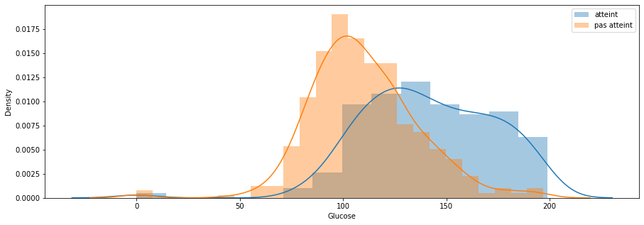

```python
plt.figure(figsize=(15,5))
sns.distplot(df_yes['Glucose'],label='atteint')
sns.distplot(df_non['Glucose'],label='pas atteint')
plt.legend()
plt.show()
```

#### $\color{blue}{\text{commentaire}}$

on constate une grande difference du taux de glucose entre les gens atteint et les gens non atteint du diabete, donc on peut poser une hypothése selon la quelle : Le taux de Glucose est un facteur determinant pour savoir si une personne est atteint ou non de diabete reste à verifier lors du traitement de nos données\ $\color{red}{\text{Ainsi nous allons consider par hypthése que la variable Glucose a un grand impact sur diabête}}$

==================================================================================================================

#### -Relation entre Target/BloodPressure

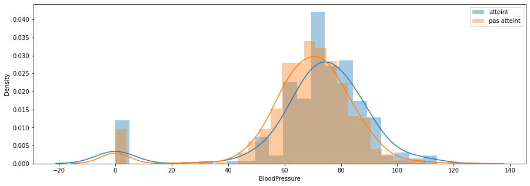

```python
plt.figure(figsize=(15,5))
sns.distplot(df_yes['BloodPressure'],label='atteint')
sns.distplot(df_non['BloodPressure'],label='pas atteint')
plt.legend()
plt.show()
```

#### $\color{blue}{\text{commentaire}}$

La visualisation des deux distributions pour cette variable nous permet de voir qu'il n y pas de difference entre la tension artérielle des gens atteints du diabête et ceux qui le sont pas.

===============================================================================================================

#### -Relation entre Target/ Age

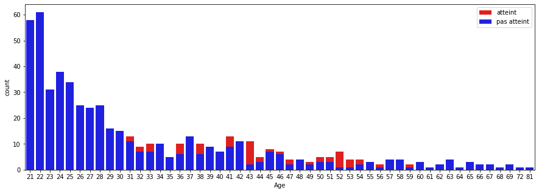

```python
plt.figure(figsize=(15,5))
sns.countplot(df_yes['Age'],color='r',label='atteint')
sns.countplot(df_non['Age'],color='b',label='pas atteint')
plt.legend()
plt.show()
```

#### $\color{blue}{\text{commentaire}}$

Avec la visualisation de l'âge des personnes on constate même si c'est pas evident que les gens qui ont moins de 31 ans atteints rarement le diabête, on note un balotage entre les gens positifs et negatives du diabete pour une age compris entre 31 ans et 40 ans,mais c'est a partir des 41 ans que les gens sont caement touché par le dibête.\ $\color{red}{\text{Ainsi nous allons consider par hypthése que la variable Age a un impact sur diabête}}$

=====================================================================================================================

#### -Relation Target/Insulin

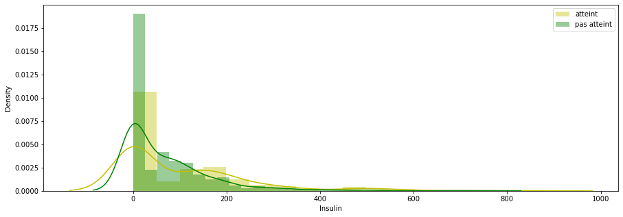

```python
plt.figure(figsize=(15,5))
sns.distplot(df_yes['Insulin'],color='y',label='atteint')
sns.distplot(df_non['Insulin'],color='g',label='pas atteint')
plt.legend()
plt.show()
```

#### $\color{blue}{\text{commentaire}}$

On constate que les des distribution sont quasi-identique d'aprés leurs visualisation donc on peut poser l'hypothese selon la quelle la variable Insulin n'a pas un grand impact sur la variable à predire

=====================================================================================================================

#### Relation Target/Pregnancies

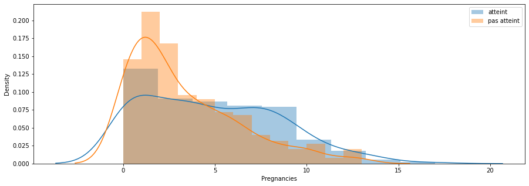

```python
plt.figure(figsize=(15,5))
sns.distplot(df_yes['Pregnancies'],label='atteint')
sns.distplot(df_non['Pregnancies'],label='pas atteint')
plt.legend()
plt.show()
```

#### $\color{blue}{\text{commentaire}}$

======================================================================================================================

#### - Relation entre Target/DiabetesPedigreeFunction

```python
df.head(1)
```

|  | Pregnancies | Glucose | BloodPressure | SkinThickness | Insulin | BMI | DiabetesPedigreeFunction | Age | Outcome |
| --- | --- | --- | --- | --- | --- | --- | --- | --- | --- |
| 0 | 6 | 148 | 72 | 35 | 0 | 33.6 | 0.627 | 50 | 1 |

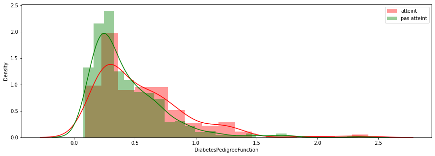

```python
plt.figure(figsize=(15,5))
sns.distplot(df_yes['DiabetesPedigreeFunction'],color='r',label='atteint')
sns.distplot(df_non['DiabetesPedigreeFunction'],color='g',label='pas atteint')
plt.legend()
plt.show()
```

#### $\color{blue}{\text{commentaire}}$

On constate que les des distribution sont quasi-identique d'aprés leurs visualisation donc on peut poser l'hypothese selon la quelle la variable DiabetesPedigreeFunction n'a pas un grand impact sur la variable à predire

# 2) Modelisation

===============================================================================================================

### A) L'algorithme : KNeighborsClassifier (Plus proche voisin)

La classification basée sur les voisins est un type d'apprentissage basé sur les instances ou apprentissage non généralisateur : elle ne tente pas de construire un modèle interne général, mais stocke simplement les instances des données d'apprentissage. La classification est calculée à partir d'un simple vote majoritaire des voisins les plus proches de chaque point : un point d'interrogation se voit attribuer la classe de données qui a le plus de représentants parmi les voisins les plus proches du point.

#### A) a) Creons notre premier model de la maniere la plus basique....

```python
from sklearn.model_selection import train_test_split
from sklearn.neighbors import KNeighborsClassifier
```

```python
x=df.drop('Outcome',axis=1)
y=df['Outcome']
```

```python
x_train,x_test,y_train,y_test=train_test_split(x,y,test_size=0.2,random_state=0)
```

```python
model=KNeighborsClassifier()
```

```python
model.fit(x_train,y_train)
c=model.score(x_test,y_test)
print('le modele donne \n ')
print('une efficacité de ',c*100,'% \n')
print('une erreur de',100-c*100,'%')
```

```
le modele donne

une efficacité de  75.32467532467533 %

une erreur de 24.675324675324674 %
```

```python
from sklearn.metrics import confusion_matrix
```

```python
y_pred=model.predict(x_test)
```

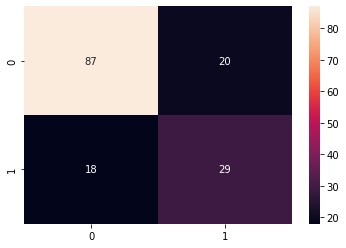

```python
sns.heatmap(confusion_matrix(y_test,y_pred),annot=True)
```

#### $\color{blue}{\text{Commentaire}}$:

```python
for k in range(3,21):
    modele=KNeighborsClassifier(k)
    modele.fit(x_train,y_train)
    score=modele.score(x_test,y_test)
    print('pour k =',k,'le modele du KNeighborsClassifier donne une score de',score*100,'%')
```

```
pour k = 3 le modele du KNeighborsClassifier donne une score de 72.07792207792207 %
pour k = 4 le modele du KNeighborsClassifier donne une score de 77.27272727272727 %
pour k = 5 le modele du KNeighborsClassifier donne une score de 75.32467532467533 %
pour k = 6 le modele du KNeighborsClassifier donne une score de 77.92207792207793 %
pour k = 7 le modele du KNeighborsClassifier donne une score de 75.97402597402598 %
pour k = 8 le modele du KNeighborsClassifier donne une score de 77.92207792207793 %
pour k = 9 le modele du KNeighborsClassifier donne une score de 77.27272727272727 %
pour k = 10 le modele du KNeighborsClassifier donne une score de 79.22077922077922 %
pour k = 11 le modele du KNeighborsClassifier donne une score de 76.62337662337663 %
pour k = 12 le modele du KNeighborsClassifier donne une score de 78.57142857142857 %
pour k = 13 le modele du KNeighborsClassifier donne une score de 79.22077922077922 %
pour k = 14 le modele du KNeighborsClassifier donne une score de 79.22077922077922 %
pour k = 15 le modele du KNeighborsClassifier donne une score de 79.22077922077922 %
pour k = 16 le modele du KNeighborsClassifier donne une score de 79.22077922077922 %
pour k = 17 le modele du KNeighborsClassifier donne une score de 78.57142857142857 %
pour k = 18 le modele du KNeighborsClassifier donne une score de 78.57142857142857 %
pour k = 19 le modele du KNeighborsClassifier donne une score de 79.87012987012987 %
pour k = 20 le modele du KNeighborsClassifier donne une score de 79.22077922077922 %
```

$\color{red}{\text{Nous allons continuer par la suite avec k=19 car le modele obtient une meilleure score(79,8%) pour K=19}}$

======================================================================================================================

#### A) b) Normalisation des données

```python
from sklearn.preprocessing import StandardScaler
```

```python
X=StandardScaler().fit_transform(x)
Y=y
```

```python
X
```

```
array([[ 0.63994726,  0.84832379,  0.14964075, ...,  0.20401277,
         0.46849198,  1.4259954 ],
       [-0.84488505, -1.12339636, -0.16054575, ..., -0.68442195,
        -0.36506078, -0.19067191],
       [ 1.23388019,  1.94372388, -0.26394125, ..., -1.10325546,
         0.60439732, -0.10558415],
       ...,
       [ 0.3429808 ,  0.00330087,  0.14964075, ..., -0.73518964,
        -0.68519336, -0.27575966],
       [-0.84488505,  0.1597866 , -0.47073225, ..., -0.24020459,
        -0.37110101,  1.17073215],
       [-0.84488505, -0.8730192 ,  0.04624525, ..., -0.20212881,
        -0.47378505, -0.87137393]])
```

```python
X_train,X_test,Y_train,Y_test=train_test_split(X,Y,test_size=0.2,random_state=0)
```

```python
model=KNeighborsClassifier(19)
```

```python
model.fit(X_train,Y_train)
b=model.score(X_test,Y_test)
print('le modele donne \n ')
print('une efficacité de ',b*100,'% \n')
print('une erreur de',100-b*100,'%')
```

```
le modele donne

une efficacité de  80.51948051948052 %

une erreur de 19.480519480519476 %
```

==================================================================================================================

```python
from sklearn.preprocessing import PolynomialFeatures
from sklearn.pipeline import make_pipeline
```

```python
scor=[]
for k in range(1,11):
    for i in range(1,10):
        mode=make_pipeline(StandardScaler(),PolynomialFeatures(i),KNeighborsClassifier(k))
        mode.fit(x_train,y_train)
        score=mode.score(x_test,y_test)
        scor.append(mode.score(x_test,y_test))

        print('Pour k =',k,'et i=',i,'on a une score de',score*100,'%')
max(scor)
```

```
Pour k = 1 et i= 1 on a une score de 73.37662337662337 %
Pour k = 1 et i= 2 on a une score de 71.42857142857143 %
Pour k = 1 et i= 3 on a une score de 69.48051948051948 %
Pour k = 1 et i= 4 on a une score de 68.83116883116884 %
Pour k = 1 et i= 5 on a une score de 69.48051948051948 %
Pour k = 1 et i= 6 on a une score de 69.48051948051948 %
Pour k = 1 et i= 7 on a une score de 68.83116883116884 %
Pour k = 1 et i= 8 on a une score de 68.83116883116884 %
Pour k = 1 et i= 9 on a une score de 70.12987012987013 %
Pour k = 2 et i= 1 on a une score de 76.62337662337663 %
Pour k = 2 et i= 2 on a une score de 77.27272727272727 %
Pour k = 2 et i= 3 on a une score de 77.27272727272727 %
Pour k = 2 et i= 4 on a une score de 74.67532467532467 %
Pour k = 2 et i= 5 on a une score de 73.37662337662337 %
Pour k = 2 et i= 6 on a une score de 74.67532467532467 %
Pour k = 2 et i= 7 on a une score de 74.67532467532467 %
Pour k = 2 et i= 8 on a une score de 73.37662337662337 %
Pour k = 2 et i= 9 on a une score de 76.62337662337663 %
Pour k = 3 et i= 1 on a une score de 74.02597402597402 %
Pour k = 3 et i= 2 on a une score de 74.67532467532467 %
Pour k = 3 et i= 3 on a une score de 74.02597402597402 %
Pour k = 3 et i= 4 on a une score de 74.02597402597402 %
Pour k = 3 et i= 5 on a une score de 74.67532467532467 %
Pour k = 3 et i= 6 on a une score de 73.37662337662337 %
Pour k = 3 et i= 7 on a une score de 74.02597402597402 %
Pour k = 3 et i= 8 on a une score de 74.67532467532467 %
Pour k = 3 et i= 9 on a une score de 75.97402597402598 %
Pour k = 4 et i= 1 on a une score de 79.22077922077922 %
Pour k = 4 et i= 2 on a une score de 73.37662337662337 %
Pour k = 4 et i= 3 on a une score de 76.62337662337663 %
Pour k = 4 et i= 4 on a une score de 78.57142857142857 %
Pour k = 4 et i= 5 on a une score de 79.87012987012987 %
Pour k = 4 et i= 6 on a une score de 78.57142857142857 %
Pour k = 4 et i= 7 on a une score de 77.92207792207793 %
Pour k = 4 et i= 8 on a une score de 74.67532467532467 %
Pour k = 4 et i= 9 on a une score de 77.27272727272727 %
Pour k = 5 et i= 1 on a une score de 79.87012987012987 %
Pour k = 5 et i= 2 on a une score de 77.92207792207793 %
Pour k = 5 et i= 3 on a une score de 77.92207792207793 %
Pour k = 5 et i= 4 on a une score de 76.62337662337663 %
```

[output cut: 35 more lines]

```
Pour k = 9 et i= 4 on a une score de 77.27272727272727 %
Pour k = 9 et i= 5 on a une score de 81.16883116883116 %
Pour k = 9 et i= 6 on a une score de 81.81818181818183 %
Pour k = 9 et i= 7 on a une score de 81.81818181818183 %
Pour k = 9 et i= 8 on a une score de 79.87012987012987 %
Pour k = 9 et i= 9 on a une score de 80.51948051948052 %
Pour k = 10 et i= 1 on a une score de 77.92207792207793 %
Pour k = 10 et i= 2 on a une score de 78.57142857142857 %
Pour k = 10 et i= 3 on a une score de 77.27272727272727 %
Pour k = 10 et i= 4 on a une score de 78.57142857142857 %
Pour k = 10 et i= 5 on a une score de 81.16883116883116 %
Pour k = 10 et i= 6 on a une score de 79.87012987012987 %
Pour k = 10 et i= 7 on a une score de 82.46753246753246 %
Pour k = 10 et i= 8 on a une score de 77.92207792207793 %
Pour k = 10 et i= 9 on a une score de 81.16883116883116 %
```

```
0.8246753246753247
```

$\color{red}{\text{on obtient une meilleure score (82,5%) pour K=10,et i=7.}}$ $\color{red}{\text{par la suite nous allons continuer avec k=10 (nombre de voisin) et i=7( degre du polynome)}}$

```python
modele= mode=make_pipeline(StandardScaler(),PolynomialFeatures(7),KNeighborsClassifier(10))
modele.fit(x_train,y_train)
d=score=modele.score(x_test,y_test)
print('le modele donne \n ')
print('une efficacité de ',d*100,'% \n')
print('une erreur de',100-d*100,'%')
```

```
le modele donne

une efficacité de  82.46753246753246 %

une erreur de 17.532467532467535 %
```

=================================================================================================================

#### Corrélation

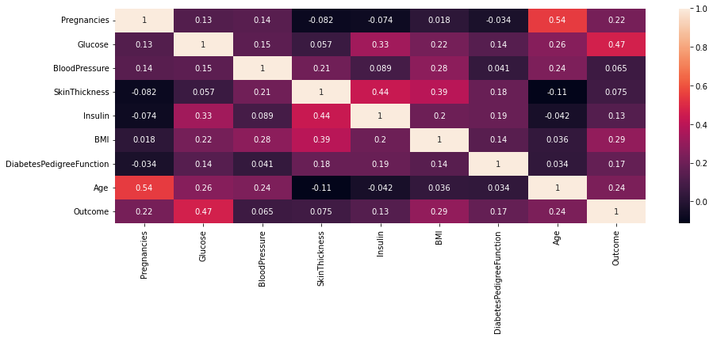

```python
plt.figure(figsize=(15,5))
sns.heatmap(df.corr(),annot=True)
plt.show()
```

====================================================================================================================

#### Selection de meilleure variable

```python
df.head(2)
```

|  | Pregnancies | Glucose | BloodPressure | SkinThickness | Insulin | BMI | DiabetesPedigreeFunction | Age | Outcome |
| --- | --- | --- | --- | --- | --- | --- | --- | --- | --- |
| 0 | 6 | 148 | 72 | 35 | 0 | 33.6 | 0.627 | 50 | 1 |
| 1 | 1 | 85 | 66 | 29 | 0 | 26.6 | 0.351 | 31 | 0 |

```python
from sklearn.feature_selection import SelectKBest,chi2
```

```python
chi2(x,y)
```

```
(array([ 111.51969064, 1411.88704064,   17.60537322,   53.10803984,
        2175.56527292,  127.66934333,    5.39268155,  181.30368904]),
 array([4.55261043e-026, 5.48728628e-309, 2.71819252e-005, 3.15697650e-013,
        0.00000000e+000, 1.32590849e-029, 2.02213728e-002, 2.51638830e-041]))
```

```python
select=SelectKBest(chi2,k=4)
select.fit_transform(x,y)
select.get_support()
```

```
array([False,  True, False, False,  True,  True, False,  True])
```

### $\color{green}{\text{les 4 variables selectionnées sont: Glucose, Insulin, BMI et L'Age}}$

====================================================================================================================

```python
df.drop(['BloodPressure','SkinThickness','DiabetesPedigreeFunction'],axis=1,inplace=True)
```

```python
x=df.drop('Outcome',axis=1)
y=df['Outcome']
```

```python
x_train,x_test,y_train,y_test=train_test_split(x,y,test_size=0.2,random_state=0)
```

```python
scor=[]
for k in range(1,7):
    for i in range(1,10):
        mode=make_pipeline(StandardScaler(),PolynomialFeatures(i),KNeighborsClassifier(k))
        mode.fit(x_train,y_train)
        score=mode.score(x_test,y_test)
        scor.append(mode.score(x_test,y_test))

        print('Pour k =',k,'et i=',i,'on a une score de',score*100,'%')
max(scor)
```

```
Pour k = 1 et i= 1 on a une score de 73.37662337662337 %
Pour k = 1 et i= 2 on a une score de 74.02597402597402 %
Pour k = 1 et i= 3 on a une score de 75.97402597402598 %
Pour k = 1 et i= 4 on a une score de 76.62337662337663 %
Pour k = 1 et i= 5 on a une score de 75.97402597402598 %
Pour k = 1 et i= 6 on a une score de 75.32467532467533 %
Pour k = 1 et i= 7 on a une score de 74.02597402597402 %
Pour k = 1 et i= 8 on a une score de 75.32467532467533 %
Pour k = 1 et i= 9 on a une score de 74.02597402597402 %
Pour k = 2 et i= 1 on a une score de 79.22077922077922 %
Pour k = 2 et i= 2 on a une score de 77.92207792207793 %
Pour k = 2 et i= 3 on a une score de 76.62337662337663 %
Pour k = 2 et i= 4 on a une score de 74.67532467532467 %
Pour k = 2 et i= 5 on a une score de 73.37662337662337 %
Pour k = 2 et i= 6 on a une score de 74.67532467532467 %
Pour k = 2 et i= 7 on a une score de 74.67532467532467 %
Pour k = 2 et i= 8 on a une score de 74.02597402597402 %
Pour k = 2 et i= 9 on a une score de 72.07792207792207 %
Pour k = 3 et i= 1 on a une score de 77.92207792207793 %
Pour k = 3 et i= 2 on a une score de 79.22077922077922 %
Pour k = 3 et i= 3 on a une score de 77.27272727272727 %
Pour k = 3 et i= 4 on a une score de 76.62337662337663 %
Pour k = 3 et i= 5 on a une score de 77.27272727272727 %
Pour k = 3 et i= 6 on a une score de 79.22077922077922 %
Pour k = 3 et i= 7 on a une score de 78.57142857142857 %
Pour k = 3 et i= 8 on a une score de 79.22077922077922 %
Pour k = 3 et i= 9 on a une score de 79.87012987012987 %
Pour k = 4 et i= 1 on a une score de 79.22077922077922 %
Pour k = 4 et i= 2 on a une score de 75.97402597402598 %
Pour k = 4 et i= 3 on a une score de 75.32467532467533 %
Pour k = 4 et i= 4 on a une score de 75.32467532467533 %
Pour k = 4 et i= 5 on a une score de 76.62337662337663 %
Pour k = 4 et i= 6 on a une score de 77.92207792207793 %
Pour k = 4 et i= 7 on a une score de 77.92207792207793 %
Pour k = 4 et i= 8 on a une score de 77.27272727272727 %
Pour k = 4 et i= 9 on a une score de 78.57142857142857 %
Pour k = 5 et i= 1 on a une score de 80.51948051948052 %
Pour k = 5 et i= 2 on a une score de 77.92207792207793 %
Pour k = 5 et i= 3 on a une score de 77.92207792207793 %
Pour k = 5 et i= 4 on a une score de 77.27272727272727 %
Pour k = 5 et i= 5 on a une score de 78.57142857142857 %
Pour k = 5 et i= 6 on a une score de 78.57142857142857 %
Pour k = 5 et i= 7 on a une score de 78.57142857142857 %
Pour k = 5 et i= 8 on a une score de 79.22077922077922 %
Pour k = 5 et i= 9 on a une score de 79.22077922077922 %
Pour k = 6 et i= 1 on a une score de 77.92207792207793 %
Pour k = 6 et i= 2 on a une score de 76.62337662337663 %
Pour k = 6 et i= 3 on a une score de 76.62337662337663 %
Pour k = 6 et i= 4 on a une score de 77.27272727272727 %
Pour k = 6 et i= 5 on a une score de 80.51948051948052 %
Pour k = 6 et i= 6 on a une score de 81.81818181818183 %
Pour k = 6 et i= 7 on a une score de 81.16883116883116 %
Pour k = 6 et i= 8 on a une score de 83.11688311688312 %
Pour k = 6 et i= 9 on a une score de 81.81818181818183 %
```

```
0.8311688311688312
```

```python
modele=make_pipeline(StandardScaler(),PolynomialFeatures(8),KNeighborsClassifier(6))
modele.fit(x_train,y_train)
d=score=modele.score(x_test,y_test)
print('le modele donne \n ')
print('une efficacité de ',d*100,'% \n')
print('une erreur de',100-d*100,'%')
```

```
le modele donne

une efficacité de  83.11688311688312 %

une erreur de 16.883116883116884 %
```

=====================================================================================================================

### B) Algorithme: LogisticRegression

La régression logistique est un algorithme de classification très répandu, offrant un\ pouvoir explicatif très fort du fait de sa linéarité.

```python
from sklearn.linear_model import LogisticRegression
```

```python
logist=LogisticRegression()
logist.fit(x_train,y_train)
l=logist.score(x_test,y_test)
print('le modele donne \n ')
print('une efficacité de ',l*100,'% \n')
print('une erreur de',100-l*100,'%')
```

```
le modele donne

une efficacité de  80.51948051948052 %

une erreur de 19.480519480519476 %
```

```python
    for i in range(1,10):
        mode=make_pipeline(StandardScaler(),PolynomialFeatures(i),LogisticRegression())
        mode.fit(x_train,y_train)
        score=mode.score(x_test,y_test)
        scor.append(mode.score(x_test,y_test))

        print('Pour i=',i,'on a une score de',score*100,'%')
```

```
Pour i= 1 on a une score de 80.51948051948052 %
Pour i= 2 on a une score de 79.87012987012987 %
Pour i= 3 on a une score de 76.62337662337663 %
Pour i= 4 on a une score de 78.57142857142857 %
```

```
Pour i= 5 on a une score de 79.22077922077922 %
```

```
Pour i= 6 on a une score de 79.22077922077922 %
```

```
Pour i= 7 on a une score de 78.57142857142857 %
```

```
Pour i= 8 on a une score de 79.87012987012987 %
Pour i= 9 on a une score de 75.32467532467533 %
```

=====================================================================================================================

#### Conclusion :

Comme on a les meilleures scores avec l'algorithme de KNeighborsClassifier vis à vis de l'algorithme de logisticregression\ nous allons conserver la meilleure score de l'algorithme de KNeighborsClassifier qui se trouve ci-apres\ dans la suite de notre travail

```python
modele=make_pipeline(StandardScaler(),PolynomialFeatures(8),KNeighborsClassifier(6))
modele.fit(x_train,y_train)
d=score=modele.score(x_test,y_test)
print('le modele donne \n ')
print('une efficacité de ',d*100,'% \n')
print('une erreur de',100-d*100,'%')
```

```
le modele donne

une efficacité de  83.11688311688312 %

une erreur de 16.883116883116884 %
```

```python
y_pred=modele.predict(x_test)
```

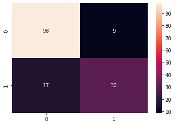

```python
sns.heatmap(confusion_matrix(y_test,y_pred),annot=True)
```

====================================================================================================================

#### Courbe d'apprentissage

```python
from sklearn.model_selection import learning_curve
```

```
[ 98 141 185 229 272 316 360 403 447 491]
```

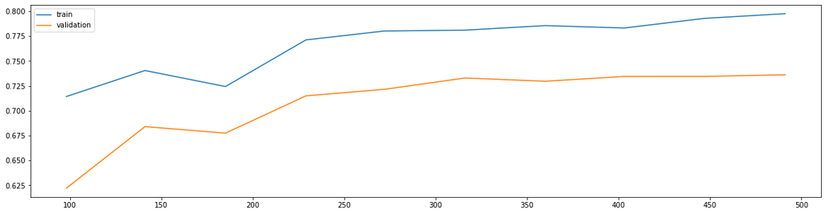

```python
plt.figure(figsize=(20,5))
N,train_score,val_score=learning_curve(modele,x_train,y_train,train_sizes=np.linspace(0.2,1.0,10),cv=5)
print(N)
plt.plot(N,train_score.mean(axis=1),label='train')
plt.plot(N,val_score.mean(axis=1),label='validation')
plt.legend()
plt.show()
```